# AI-Fall 03-CA2

## University

University of Tehran

## Student Info

Amirhossein Arefzadeh - std id: 810101604

## Project Overview

This project explores the application of two distinct algorithmic approaches (genetic algorithms and minimax algorithms) in the context of game strategy and image generation. The goal is to understand and analyze their effectiveness, performance, and adaptability in solving complex problems within these domains.

# Genetic

[figure not shown]

```python
import random
from PIL import Image, ImageDraw
import numpy as np
import cv2
import os
from copy import deepcopy
from PIL import Image
import matplotlib.pyplot as plt
```

```python
OFFSET = 10

def generate_point(width, height):
    x = random.randrange(0 - OFFSET, width + OFFSET, 1)
    y = random.randrange(0 - OFFSET, height + OFFSET, 1)
    return (x, y)

class Triangle:
    def __init__(self, img_width, img_height):
        self.points = []
        for i in range(3):
            self.points.append(generate_point(img_width,img_height))


        self.color = (
            random.randint(0, 255),
            random.randint(0, 255),
            random.randint(0, 255),
            random.randint(0, 255),
        )

        self._img_width = img_width
        self._img_height = img_height

    def duplicate(self):
        t = Triangle(self._img_width, self._img_height)
        t.color = self.color
        t.points = self.points.copy()
        return t
```

```python
class Chromosome:
    def __init__(self,img_height, img_width,target_image,num_triangles):
        self.img_height = img_height
        self.img_width = img_width
        self.background_color = (0,0,0,255)
        self.triangles = []
        self.target_image = target_image
        self.num_trinagles = num_triangles
        for _ in range(self.num_trinagles):
            triangle = Triangle(self.img_width, self.img_height)
            self.triangles.append(triangle)

    def draw(self) -> Image:
        size = self.target_image.size
        img = Image.new('RGB', size, self.background_color)
        draw = Image.new('RGBA', size)
        pdraw = ImageDraw.Draw(draw)
        for triangle in self.triangles:
            colour = triangle.color
            points = triangle.points
            pdraw.polygon(points, fill=colour, outline=colour)
            img.paste(draw, mask=draw)
        return img
```

## Mutate

The `mutate` function applies a mutation operation to a randomly selected triangle within a chromosome. This function introduces controlled randomness into the genetic algorithm, allowing the generated image to evolve by slightly altering the properties of its components (triangles) in various ways. By including multiple mutation types, this approach increases diversity in potential solutions, helping the algorithm escape local optima and explore a broader solution space.

The function follows these steps:

1. **Mutation Selection:** Four types of mutations are available, with associated weights to control their likelihood of selection:
   - **Shift Mutation:** Randomly shifts all vertices of the selected triangle by an integer offset in both x and y directions.
   - **Point Mutation:** Alters the coordinates of each triangle vertex individually, constrained by the image boundaries to ensure vertices remain within bounds.
   - **Color Mutation:** Adjusts the color of the triangle by randomly increasing or decreasing each RGB component, keeping values within the range ([0, 255]).
   - **Reset Mutation:** Replaces the selected triangle with a new randomly generated triangle, resetting both its points and color.
2. **Execution:** The function randomly selects one of the mutation types based on the specified weights and applies it to the chosen triangle.

By employing this mutation mechanism, the genetic algorithm achieves diversity and adaptability in the generated images, as each mutation type promotes a different kind of variation. This diversity is critical for driving the evolutionary process forward, as it enables gradual improvements in fitness over successive generations.

```python
def mutate(self):
    mutations = ['shift', 'point', 'color', 'reset']
    weights = [25, 30, 40, 5]
    triangle = random.choice(self.triangles)

    mutation_type = random.choices(mutations, weights=weights, k=1)[0]
    if mutation_type == 'shift':
        x_shift = random.randint(-10, 10)
        y_shift = random.randint(-10, 10)
        triangle.points = [(x + x_shift, y + y_shift) for x, y in triangle.points]
    elif mutation_type == 'point':
        for j in range(3):
          new_x = min(self.img_width, max(0, triangle.points[j][0] + random.randint(-20, 20)))
          new_y = min(self.img_height, max(0, triangle.points[j][1] + random.randint(-20, 20)))
          triangle.points[j] = (new_x , new_y)
    elif mutation_type == 'color':
        triangle.color = tuple(
            max(0, min(255, c + random.randint(-20, 20))) for c in triangle.color
        )
    elif mutation_type == 'reset':
        new_triangle = Triangle(self.img_width, self.img_height)
        triangle.points = new_triangle.points
        triangle.color = new_triangle.color

Chromosome.mutate = mutate
```

## Fitness Evaluation

### Mean Squared Error (MSE) Fitness

The `mse_fitness` function evaluates the fitness of a generated image by calculating the Mean Squared Error (MSE) between it and the target image. MSE is a commonly used metric for measuring the average of the squared differences between corresponding pixel values, making it sensitive to large differences and ideal for penalizing substantial deviations from the target.

In the function:

1. Both the generated and target images are converted to arrays to allow element-wise operations.
2. The MSE value, `diff`, is computed as the mean of the squared differences between corresponding pixels: $$ \text{MSE} = \frac{1}{N} \sum_{i=1}^{N} \left( (R_{\text{target},i} - R_{\text{created},i})^2 + (G_{\text{target},i} - G_{\text{created},i})^2 + (B_{\text{target},i} - B_{\text{created},i})^2 \right) $$ where ( N ) is the total number of pixels in the image.
3. A lower MSE value indicates a closer resemblance to the target image, as it implies smaller differences on average between the pixel values of the generated and target images.

The MSE metric is particularly useful in scenarios where significant deviations from the target image are heavily penalized, driving the genetic algorithm to refine the image closer to the target at each iteration.

```python
def mse_fitness(self) -> float:
    created_image = np.array(self.draw())
    target_image_array = np.array(self.target_image)
    diff = np.mean((created_image - target_image_array) ** 2)
    return diff

Chromosome.mse_fitness = mse_fitness
```

### Difference Fitness

The `diff_fitness` function evaluates the fitness of a generated image by measuring the absolute pixel-wise difference between it and the target image. This method calculates the sum of absolute differences for each pixel, providing a straightforward metric for similarity. Unlike the Delta E fitness method, which accounts for human perception in color differences, this approach directly compares the RGB values of each pixel.

In the function:

1. The generated image and the target image are converted to arrays for pixel-wise operations.
2. The fitness value, `diff`, is calculated as the sum of the absolute differences between corresponding pixel values: $$ \text{diff} = \sum |R_{\text{target}} - R_{\text{created}}| + |G_{\text{target}} - G_{\text{created}}| + |B_{\text{target}} - B_{\text{created}}| $$
3. A lower `diff` score signifies a closer match between the generated and target images, guiding the genetic algorithm toward producing images that better resemble the target.

This fitness function is simpler and computationally less intensive than Delta E, making it suitable for cases where speed is prioritized over color accuracy in visual similarity.

```python
def diff_fitness(self) -> float:
    created_image = np.array(self.draw())
    target_image_array = np.array(self.target_image)
    diff = np.sum(np.abs(created_image - target_image_array))
    return diff

Chromosome.diff_fitness = diff_fitness
```

### Delta E Fitness

A lower fitness score indicates a closer resemblance to the target image, guiding the genetic algorithm to evolve towards a more accurate representation.

link of refrence: https://github.com/SebastianCharmot/Genetic-Algorithm-Image-Recreation?tab=readme-ov-file#initial-population

```python
def deltaE_fitness(self):
    created_image = np.array(self.draw()).astype(np.float32)
    target_image_array = np.array(self.target_image).astype(np.float32)
    delta_e = np.sqrt(np.sum((target_image_array - created_image) ** 2, axis=-1))
    self.fitness = np.mean(delta_e)
    return self.fitness

Chromosome.deltaE_fitness = deltaE_fitness
```

```python
class GeneticAlgorithm():
    def __init__(self,max_width,max_height,target_image, population_size, triangles_number):
        self.population_size = population_size
        self.max_width = max_width
        self.max_height = max_height
        self.population = [Chromosome(max_height,max_width,target_image, triangles_number) for i in range(population_size)]
        self.target_image = target_image
        self.num_triangles = triangles_number

        self.best_fitness = []
        self.average_fitness = []
        self.worst_fitness = []

    def calc_fitnesses(self):
        fitnesses = []
        for chromosome in self.population:
            fitnesses.append(chromosome.deltaE_fitness())
        return fitnesses

    def sort_population(self, fitnesses):
        return [x for _, x in sorted(zip(fitnesses, self.population), key=lambda pair: pair[0])]

    def mutation(self,next_gen):
      for chromosome in next_gen:
        chromosome.mutate_color_points()

    def run(self, n_generations):
        save_dir = "generation_images"
        os.makedirs(save_dir, exist_ok=True)

        for iteration in range(n_generations):
            fitnesses = self.calc_fitnesses()

            best_fitness_val = np.min(fitnesses)
            avg_fitness_val = np.mean(fitnesses)
            worst_fitness_val = np.max(fitnesses)

            self.best_fitness.append(best_fitness_val)
            self.average_fitness.append(avg_fitness_val)
            self.worst_fitness.append(worst_fitness_val)

            if iteration % 10 == 0:
                fit_arr = np.array(fitnesses)
                print(f"Fitness in Generation {iteration}: mean: {np.mean(fit_arr)}, max: {np.max(fit_arr)}, min: {np.min(fit_arr)}")

                if iteration % 100 == 0:
                    best_chromosome = self.sort_population(fitnesses)[0]
                    best_image = best_chromosome.draw()
                    best_image.save(os.path.join(save_dir, f"gen_{iteration}.png"))

            self.sel_from_best(fitnesses)

    def get_best_of_population(self):
        fitnesses = self.calc_fitnesses()
        best_population = self.sort_population(fitnesses)
        image = best_population.draw()
        cv2.imshow("Reconstructed Image", np.array(image))
        cv2.waitKey(0)
        cv2.destroyAllWindows()
```

## Crossover

The `uniform_cross_over` function generates offspring from two parent chromosomes by combining their triangle components. This crossover method is designed to promote genetic diversity by randomly mixing elements from both parents, which helps the genetic algorithm explore a wider solution space and evolve towards more optimal solutions.

The function works as follows:

1. **Child Initialization:** Two child chromosomes are created, initialized with the same properties as the parents (e.g., image dimensions, target image, and number of triangles).
2. **Triangle Selection:** For each triangle in the chromosome:
   - A random decision (with a 50% probability) determines whether a triangle from `parent1` or `parent2` will be inherited by `child1`. The opposite triangle is assigned to `child2`.
   - The `.duplicate()` method ensures that the triangle object is copied rather than referenced, maintaining independence of the children's genetic structure.
3. **Output:** The function returns `child1` and `child2` as the new offspring.

This uniform crossover approach ensures that each child inherits an equal mix of traits from both parents, leading to a balanced transfer of genetic material. By preserving variation between generations, this crossover method increases the likelihood of generating novel and potentially more fit solutions as the genetic algorithm progresses.

```python
def uniform_cross_over(self, parent1, parent2):
    child1 = Chromosome(self.max_height, self.max_width, self.target_image, self.num_triangles)
    child2 = Chromosome(self.max_height, self.max_width, self.target_image, self.num_triangles)

    for i in range(self.num_triangles):
        if random.random() < 0.5:
            child1.triangles[i] = parent1.triangles[i].duplicate()
            child2.triangles[i] = parent2.triangles[i].duplicate()
        else:
            child1.triangles[i] = parent2.triangles[i].duplicate()
            child2.triangles[i] = parent1.triangles[i].duplicate()

    return child1, child2

GeneticAlgorithm.uniform_cross_over = uniform_cross_over
```

## next generation selection policy

The `select_from_best` function is responsible for creating the next generation of the population by selecting top-performing individuals (or "elites") and generating new offspring from a set of high-fitness parents. This selection process is integral to the genetic algorithm's ability to refine the population toward optimal solutions over successive generations.

The function operates as follows:

1. **Population Sorting:** The population is first sorted based on fitness, with the most fit individuals at the start of `sorted_population`.
2. **Elite Selection:** A subset of the best-performing individuals, termed "elites" (top 10% of the population), is directly carried over to the next generation, ensuring that high-fitness solutions are preserved.
3. **Parent Pool:** A larger set of top individuals (50% of the population) is selected as potential parents for crossover operations.
4. **Crossover and Mutation:** While the next generation is filled:
   - Two parents are randomly chosen from the parent pool to create two children via `uniform_cross_over`.
   - Each child undergoes mutation to introduce variability, helping the algorithm explore new solutions.
5. **Population Update:** Once the next generation reaches the designated population size, it becomes the new population for the genetic algorithm.

By combining elite retention and selective breeding, the `select_from_best` function effectively balances exploitation of the best current solutions with exploration of new variations, which is essential for the evolutionary process of the genetic algorithm.

```python
def sel_from_best(self, fitnesses):
    sorted_population = self.sort_population(fitnesses)
    next_gen = []
    num_elites = int(0.1 * self.population_size)
    elites = sorted_population[:num_elites]
    next_gen.extend(elites)

    num_parents = int(0.5 * self.population_size)
    parents = sorted_population[:num_parents]
    while len(next_gen) < self.population_size:
        parent1, parent2 = random.sample(parents, 2)
        child1, child2 = self.uniform_cross_over(deepcopy(parent1), deepcopy(parent2))
        child1.mutate()
        child2.mutate()

        next_gen.extend([deepcopy(child1), deepcopy(child2)])

    self.population = next_gen[:self.population_size]

GeneticAlgorithm.sel_from_best = sel_from_best
```

```python
import matplotlib.pyplot as plt

def plot_fitness(self):
    generations = range(len(self.best_fitness))
    plt.plot(generations, self.best_fitness, label='Best Fitness', color='blue')
    plt.plot(generations, self.average_fitness, label='Average Fitness', color='green')
    plt.plot(generations, self.worst_fitness, label='Worst Fitness', color='red')
    plt.xlabel("Generation")
    plt.ylabel("Fitness (Error)")
    plt.title("Fitness Over Generations")
    plt.legend()
    plt.show()

GeneticAlgorithm.plot_fitness = plot_fitness
```

```python
def resize(image,max_size):
    new_width = int((max_size/max(image.size[0],image.size[1]))* image.size[0])
    new_height = int((max_size/max(image.size[0],image.size[1]))* image.size[1])
    image = image.resize((new_width,new_height), resample=Image.Resampling.LANCZOS)
    return image
```

## Analyse the Result

### genetic algorithm's performance with a population size of 50

```python
target_image_path = "C:/Users/Amir/Desktop/دانشگاه/AI/CAs/Genetic-and-Minimax-Algorithms/target_images/eagle.jpg"
image = Image.open(target_image_path)
image = resize(image,100)

width,height = image.size
population_size = 50
triangles_number = 100
alg = GeneticAlgorithm(width,height,image, population_size,triangles_number)
alg.run(3010)
```

```
Fitness in Generation 0: mean: 177.17205810546875, max: 206.68765258789062, min: 153.795166015625
Fitness in Generation 10: mean: 117.1265640258789, max: 129.4723358154297, min: 110.73896789550781
Fitness in Generation 20: mean: 104.56256866455078, max: 106.67964935302734, min: 102.47047424316406
Fitness in Generation 30: mean: 96.60272216796875, max: 103.9876708984375, min: 95.62039947509766
Fitness in Generation 40: mean: 93.83578491210938, max: 98.2667007446289, min: 91.31939697265625
Fitness in Generation 50: mean: 88.81329345703125, max: 92.7431411743164, min: 87.25321960449219
Fitness in Generation 60: mean: 84.19245910644531, max: 93.06659698486328, min: 82.89982604980469
Fitness in Generation 70: mean: 81.61769104003906, max: 84.2198486328125, min: 80.80056762695312
Fitness in Generation 80: mean: 79.29232025146484, max: 80.71562194824219, min: 78.2960205078125
Fitness in Generation 90: mean: 76.29753112792969, max: 80.32821655273438, min: 75.48100280761719
Fitness in Generation 100: mean: 72.7927017211914, max: 75.07251739501953, min: 71.0665283203125
Fitness in Generation 110: mean: 70.3855972290039, max: 73.2660140991211, min: 69.82057189941406
Fitness in Generation 120: mean: 68.10470581054688, max: 69.51248931884766, min: 67.70996856689453
Fitness in Generation 130: mean: 66.94507598876953, max: 75.5755615234375, min: 66.17015838623047
Fitness in Generation 140: mean: 64.08409118652344, max: 65.8376693725586, min: 63.10519790649414
Fitness in Generation 150: mean: 62.46238327026367, max: 63.694091796875, min: 62.04944610595703
Fitness in Generation 160: mean: 61.328739166259766, max: 67.32757568359375, min: 60.76997756958008
Fitness in Generation 170: mean: 59.53797912597656, max: 60.66019821166992, min: 59.14603042602539
Fitness in Generation 180: mean: 56.93279266357422, max: 58.7791862487793, min: 56.07273864746094
Fitness in Generation 190: mean: 56.42506790161133, max: 69.19041442871094, min: 55.53423309326172
Fitness in Generation 200: mean: 55.45331573486328, max: 61.80935287475586, min: 55.021629333496094
Fitness in Generation 210: mean: 54.821170806884766, max: 56.82103729248047, min: 54.636451721191406
Fitness in Generation 220: mean: 55.077388763427734, max: 75.47657012939453, min: 54.170162200927734
Fitness in Generation 230: mean: 53.769248962402344, max: 57.42424392700195, min: 53.47764205932617
Fitness in Generation 240: mean: 53.1712760925293, max: 54.336978912353516, min: 52.901084899902344
Fitness in Generation 250: mean: 53.04547882080078, max: 61.151771545410156, min: 52.69363784790039
Fitness in Generation 260: mean: 52.48371887207031, max: 54.038997650146484, min: 52.26299285888672
Fitness in Generation 270: mean: 52.34022903442383, max: 54.33894348144531, min: 52.1043815612793
Fitness in Generation 280: mean: 51.8892936706543, max: 57.19807815551758, min: 51.50680923461914
Fitness in Generation 290: mean: 51.442161560058594, max: 52.37310791015625, min: 51.33064270019531
Fitness in Generation 300: mean: 51.46180725097656, max: 53.8679084777832, min: 51.142879486083984
Fitness in Generation 310: mean: 50.41904830932617, max: 53.34136199951172, min: 50.00423812866211
Fitness in Generation 320: mean: 49.74970626831055, max: 51.604820251464844, min: 49.664554595947266
Fitness in Generation 330: mean: 49.420875549316406, max: 51.52652359008789, min: 49.28822326660156
Fitness in Generation 340: mean: 49.4272575378418, max: 53.621212005615234, min: 49.1932373046875
Fitness in Generation 350: mean: 48.681114196777344, max: 52.0913200378418, min: 48.08591842651367
Fitness in Generation 360: mean: 47.239173889160156, max: 49.2532844543457, min: 46.8440055847168
Fitness in Generation 370: mean: 46.690589904785156, max: 50.14126968383789, min: 46.41550827026367
Fitness in Generation 380: mean: 46.29868698120117, max: 52.457820892333984, min: 45.5249137878418
Fitness in Generation 390: mean: 45.440975189208984, max: 50.785152435302734, min: 44.7763557434082
```

[output cut: 246 more lines]

```
Fitness in Generation 2860: mean: 26.14971351623535, max: 50.157135009765625, min: 25.150711059570312
Fitness in Generation 2870: mean: 25.552587509155273, max: 32.467098236083984, min: 25.14916229248047
Fitness in Generation 2880: mean: 26.127796173095703, max: 40.833343505859375, min: 25.14731216430664
Fitness in Generation 2890: mean: 25.381654739379883, max: 28.12614631652832, min: 25.143831253051758
Fitness in Generation 2900: mean: 25.99825668334961, max: 36.504920959472656, min: 25.097030639648438
Fitness in Generation 2910: mean: 25.5125789642334, max: 30.117238998413086, min: 25.09463119506836
Fitness in Generation 2920: mean: 25.536209106445312, max: 30.776893615722656, min: 25.092933654785156
Fitness in Generation 2930: mean: 25.281599044799805, max: 29.907527923583984, min: 25.08831214904785
Fitness in Generation 2940: mean: 25.538654327392578, max: 31.97474479675293, min: 25.04924201965332
Fitness in Generation 2950: mean: 25.36397933959961, max: 30.116981506347656, min: 25.008861541748047
Fitness in Generation 2960: mean: 25.266576766967773, max: 27.69305419921875, min: 24.998586654663086
Fitness in Generation 2970: mean: 25.665233612060547, max: 42.48607635498047, min: 24.996517181396484
Fitness in Generation 2980: mean: 25.354982376098633, max: 28.818872451782227, min: 24.996517181396484
Fitness in Generation 2990: mean: 25.218549728393555, max: 28.822935104370117, min: 24.992591857910156
Fitness in Generation 3000: mean: 26.023717880249023, max: 39.37479782104492, min: 24.985761642456055
```

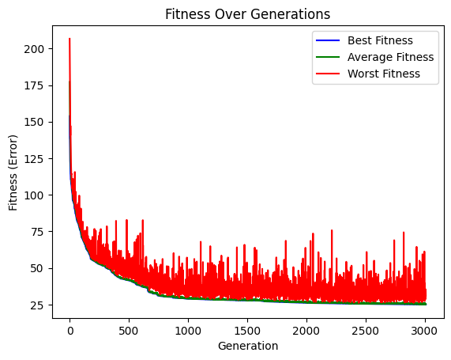

```python
alg.plot_fitness()
```

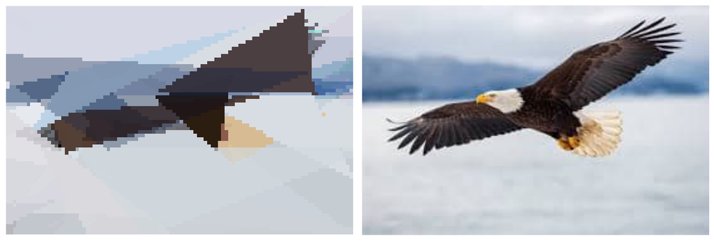

```python
target_image_path_1 = 'C:/Users/Amir/Desktop/دانشگاه/AI/CAs/Genetic-and-Minimax-Algorithms/generation_images/gen_3000.png'
target_image_path_2 = 'C:/Users/Amir/Desktop/دانشگاه/AI/CAs/Genetic-and-Minimax-Algorithms/target_images/eagle.jpg'
image1 = Image.open(target_image_path_1)
image2 = Image.open(target_image_path_2)

fig, axes = plt.subplots(1, 2, figsize=(12, 6))

axes[0].imshow(image1)
axes[0].axis('off')

axes[1].imshow(image2)
axes[1].axis('off')

plt.tight_layout()
plt.show()
```

```
Fitness in Generation 0: mean: 172.12391662597656, max: 191.97329711914062, min: 144.26327514648438
Fitness in Generation 10: mean: 112.19731903076172, max: 128.13311767578125, min: 104.30782318115234
Fitness in Generation 20: mean: 96.39741516113281, max: 98.74469757080078, min: 94.27507781982422
Fitness in Generation 30: mean: 89.11117553710938, max: 92.20457458496094, min: 87.45319366455078
Fitness in Generation 40: mean: 81.3199691772461, max: 85.00153350830078, min: 79.80377197265625
Fitness in Generation 50: mean: 74.89141082763672, max: 84.12100219726562, min: 73.1672134399414
Fitness in Generation 60: mean: 71.5787582397461, max: 74.64326477050781, min: 70.83735656738281
Fitness in Generation 70: mean: 67.23536682128906, max: 69.32112884521484, min: 65.80756378173828
Fitness in Generation 80: mean: 64.51512145996094, max: 66.79435729980469, min: 63.39682388305664
Fitness in Generation 90: mean: 62.85850143432617, max: 88.11827850341797, min: 61.693626403808594
Fitness in Generation 100: mean: 61.29561233520508, max: 64.20323181152344, min: 60.39352798461914
Fitness in Generation 110: mean: 59.54133987426758, max: 86.9511947631836, min: 58.19140625
Fitness in Generation 120: mean: 56.91399002075195, max: 74.56273651123047, min: 55.629302978515625
Fitness in Generation 130: mean: 54.7028694152832, max: 57.8537483215332, min: 54.07548904418945
Fitness in Generation 140: mean: 53.460174560546875, max: 68.53976440429688, min: 52.64743423461914
Fitness in Generation 150: mean: 52.03508758544922, max: 57.489715576171875, min: 51.25537872314453
Fitness in Generation 160: mean: 50.60099792480469, max: 55.19778823852539, min: 50.221458435058594
Fitness in Generation 170: mean: 49.945674896240234, max: 52.05564880371094, min: 49.68830871582031
Fitness in Generation 180: mean: 49.4300537109375, max: 50.059383392333984, min: 49.25151824951172
Fitness in Generation 190: mean: 49.101654052734375, max: 60.26897430419922, min: 48.519386291503906
Fitness in Generation 200: mean: 48.30332565307617, max: 54.155094146728516, min: 47.84273147583008
Fitness in Generation 210: mean: 47.78258514404297, max: 56.73972702026367, min: 47.450782775878906
Fitness in Generation 220: mean: 46.08309555053711, max: 59.15248107910156, min: 45.08316421508789
Fitness in Generation 230: mean: 44.50394058227539, max: 57.30472946166992, min: 43.33195114135742
Fitness in Generation 240: mean: 43.288169860839844, max: 55.02351760864258, min: 42.89138412475586
Fitness in Generation 250: mean: 42.77321243286133, max: 45.033843994140625, min: 42.52981185913086
Fitness in Generation 260: mean: 42.4337043762207, max: 52.492027282714844, min: 41.65862274169922
Fitness in Generation 270: mean: 40.87033462524414, max: 44.678104400634766, min: 40.377830505371094
Fitness in Generation 280: mean: 39.38795852661133, max: 45.322113037109375, min: 38.6428108215332
Fitness in Generation 290: mean: 39.21825408935547, max: 53.646358489990234, min: 38.09558868408203
Fitness in Generation 300: mean: 38.15654754638672, max: 41.38221740722656, min: 37.895877838134766
Fitness in Generation 310: mean: 39.13775634765625, max: 82.71517181396484, min: 37.14340591430664
Fitness in Generation 320: mean: 37.2081298828125, max: 47.262393951416016, min: 36.62208938598633
Fitness in Generation 330: mean: 36.97708511352539, max: 51.963172912597656, min: 36.47699737548828
Fitness in Generation 340: mean: 36.49827575683594, max: 40.26472473144531, min: 36.24839401245117
Fitness in Generation 350: mean: 36.4091682434082, max: 53.008888244628906, min: 35.86687088012695
Fitness in Generation 360: mean: 36.1682014465332, max: 43.84115219116211, min: 35.82429122924805
Fitness in Generation 370: mean: 36.20038986206055, max: 52.77632141113281, min: 35.64010238647461
Fitness in Generation 380: mean: 35.39004898071289, max: 39.41514587402344, min: 34.92692184448242
Fitness in Generation 390: mean: 35.188133239746094, max: 42.63228988647461, min: 34.679283142089844
```

[output cut: 246 more lines]

```
Fitness in Generation 2860: mean: 27.955810546875, max: 90.2379150390625, min: 26.740341186523438
Fitness in Generation 2870: mean: 28.135663986206055, max: 95.99683380126953, min: 26.73316192626953
Fitness in Generation 2880: mean: 27.46916389465332, max: 41.96315002441406, min: 26.722257614135742
Fitness in Generation 2890: mean: 26.83534812927246, max: 28.369895935058594, min: 26.71920394897461
Fitness in Generation 2900: mean: 27.35387420654297, max: 60.23517990112305, min: 26.717151641845703
Fitness in Generation 2910: mean: 27.39882469177246, max: 51.8131103515625, min: 26.530458450317383
Fitness in Generation 2920: mean: 27.384456634521484, max: 55.799373626708984, min: 26.528579711914062
Fitness in Generation 2930: mean: 26.696535110473633, max: 31.14824867248535, min: 26.52750015258789
Fitness in Generation 2940: mean: 27.03652000427246, max: 36.23195266723633, min: 26.525352478027344
Fitness in Generation 2950: mean: 27.787704467773438, max: 52.93476867675781, min: 26.51413917541504
Fitness in Generation 2960: mean: 27.01552391052246, max: 41.41765594482422, min: 26.511192321777344
Fitness in Generation 2970: mean: 26.81528663635254, max: 36.69564437866211, min: 26.510602951049805
Fitness in Generation 2980: mean: 27.091684341430664, max: 45.677608489990234, min: 26.509727478027344
Fitness in Generation 2990: mean: 26.889354705810547, max: 34.702022552490234, min: 26.495004653930664
Fitness in Generation 3000: mean: 26.89088249206543, max: 36.882503509521484, min: 26.494136810302734
```

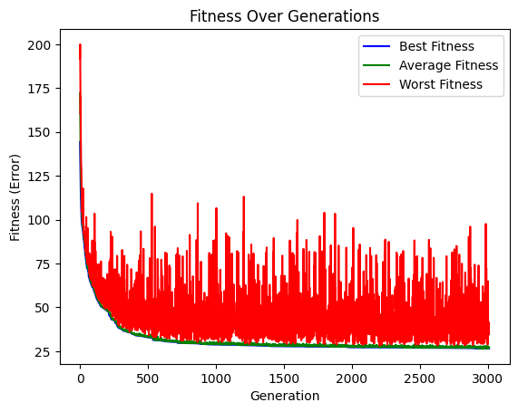

```python
target_image_path = "C:/Users/Amir/Desktop/دانشگاه/AI/CAs/Genetic-and-Minimax-Algorithms/target_images/eagle.jpg"
image = Image.open(target_image_path)
image = resize(image,100)

width,height = image.size
population_size = 75
triangles_number = 100
alg = GeneticAlgorithm(width,height,image, population_size,triangles_number)
alg.run(3010)
alg.plot_fitness()
```

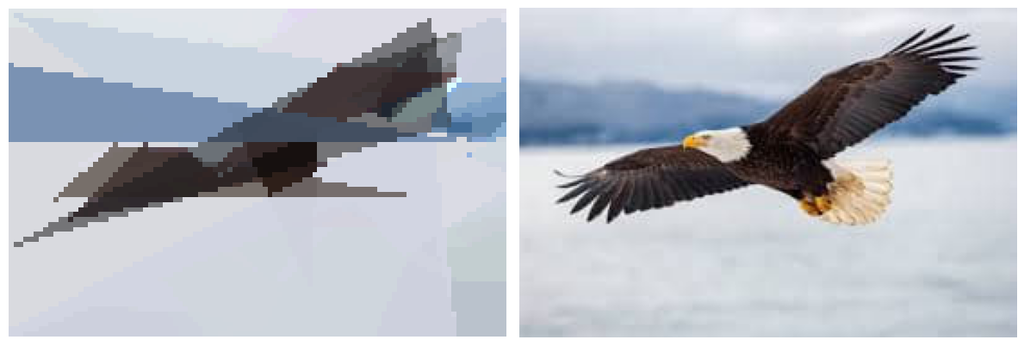

```python
target_image_path_1 = 'C:/Users/Amir/Desktop/دانشگاه/AI/CAs/Genetic-and-Minimax-Algorithms/generation_images/gen_3000.png'
target_image_path_2 = 'C:/Users/Amir/Desktop/دانشگاه/AI/CAs/Genetic-and-Minimax-Algorithms/target_images/eagle.jpg'
image1 = Image.open(target_image_path_1)
image2 = Image.open(target_image_path_2)

fig, axes = plt.subplots(1, 2, figsize=(12, 6))

axes[0].imshow(image1)
axes[0].axis('off')

axes[1].imshow(image2)
axes[1].axis('off')

plt.tight_layout()
plt.show()
```

```python
target_image_path = "C:/Users/Amir/Desktop/دانشگاه/AI/CAs/Genetic-and-Minimax-Algorithms/target_images/eagle.jpg"
image = Image.open(target_image_path)
image = resize(image,100)

width,height = image.size
population_size = 100
triangles_number = 100
alg = GeneticAlgorithm(width,height,image, population_size,triangles_number)
alg.run(3010)
```

```
Fitness in Generation 0: mean: 171.1269073486328, max: 209.96322631835938, min: 138.4316864013672
Fitness in Generation 10: mean: 109.21060180664062, max: 127.57923889160156, min: 98.31983184814453
Fitness in Generation 20: mean: 92.64806365966797, max: 104.40386199951172, min: 89.26083374023438
Fitness in Generation 30: mean: 84.81147766113281, max: 88.42206573486328, min: 82.58702850341797
Fitness in Generation 40: mean: 79.96870422363281, max: 88.71805572509766, min: 76.7473373413086
Fitness in Generation 50: mean: 72.7466049194336, max: 78.50086212158203, min: 71.8208236694336
Fitness in Generation 60: mean: 68.93562316894531, max: 73.53129577636719, min: 67.81025695800781
Fitness in Generation 70: mean: 64.99886322021484, max: 67.26385498046875, min: 63.818599700927734
Fitness in Generation 80: mean: 61.7751350402832, max: 68.14893341064453, min: 61.086334228515625
Fitness in Generation 90: mean: 59.33890151977539, max: 70.89485168457031, min: 57.95075607299805
Fitness in Generation 100: mean: 56.33719253540039, max: 61.91910934448242, min: 55.60873031616211
Fitness in Generation 110: mean: 54.37353515625, max: 67.6662368774414, min: 53.04212188720703
Fitness in Generation 120: mean: 52.011077880859375, max: 55.556644439697266, min: 51.268333435058594
Fitness in Generation 130: mean: 50.64030456542969, max: 56.782264709472656, min: 50.04006576538086
Fitness in Generation 140: mean: 49.20455551147461, max: 60.420738220214844, min: 48.02952575683594
Fitness in Generation 150: mean: 47.39732360839844, max: 52.35696792602539, min: 46.67927932739258
Fitness in Generation 160: mean: 46.648677825927734, max: 73.55205535888672, min: 45.26700210571289
Fitness in Generation 170: mean: 44.885154724121094, max: 55.75935745239258, min: 43.93342971801758
Fitness in Generation 180: mean: 43.32558059692383, max: 63.150672912597656, min: 42.63080596923828
Fitness in Generation 190: mean: 42.26529312133789, max: 59.73899459838867, min: 40.92760467529297
Fitness in Generation 200: mean: 40.6679801940918, max: 46.44046401977539, min: 39.92314529418945
Fitness in Generation 210: mean: 39.993309020996094, max: 53.048484802246094, min: 39.18110656738281
Fitness in Generation 220: mean: 38.8821907043457, max: 40.35169219970703, min: 38.6170768737793
Fitness in Generation 230: mean: 38.51850891113281, max: 46.48842239379883, min: 38.27769470214844
Fitness in Generation 240: mean: 38.2829704284668, max: 42.64986801147461, min: 37.938446044921875
Fitness in Generation 250: mean: 38.062843322753906, max: 52.97496032714844, min: 37.62449264526367
Fitness in Generation 260: mean: 37.62740707397461, max: 42.789100646972656, min: 37.3276252746582
Fitness in Generation 270: mean: 37.31678771972656, max: 45.80009078979492, min: 37.00202560424805
Fitness in Generation 280: mean: 37.234230041503906, max: 54.437747955322266, min: 36.48845291137695
Fitness in Generation 290: mean: 36.959510803222656, max: 55.31758499145508, min: 35.979373931884766
Fitness in Generation 300: mean: 36.32353591918945, max: 54.76622009277344, min: 35.58613967895508
Fitness in Generation 310: mean: 36.197303771972656, max: 60.032718658447266, min: 35.35295104980469
Fitness in Generation 320: mean: 35.5208854675293, max: 40.981998443603516, min: 35.18587875366211
Fitness in Generation 330: mean: 35.191253662109375, max: 41.40532302856445, min: 35.00810623168945
Fitness in Generation 340: mean: 35.44343566894531, max: 60.75690841674805, min: 34.695438385009766
Fitness in Generation 350: mean: 34.534584045410156, max: 37.59373474121094, min: 34.17959213256836
Fitness in Generation 360: mean: 34.045841217041016, max: 44.9467887878418, min: 33.418067932128906
Fitness in Generation 370: mean: 33.536441802978516, max: 43.91435623168945, min: 32.564205169677734
Fitness in Generation 380: mean: 32.92806625366211, max: 52.09134292602539, min: 32.45288848876953
Fitness in Generation 390: mean: 32.632965087890625, max: 44.1469841003418, min: 32.295528411865234
```

[output cut: 246 more lines]

```
Fitness in Generation 2860: mean: 23.254159927368164, max: 49.971771240234375, min: 22.34392738342285
Fitness in Generation 2870: mean: 22.69281578063965, max: 33.28303146362305, min: 22.343034744262695
Fitness in Generation 2880: mean: 22.552812576293945, max: 28.0869083404541, min: 22.325448989868164
Fitness in Generation 2890: mean: 22.65634536743164, max: 31.26019859313965, min: 22.324077606201172
Fitness in Generation 2900: mean: 22.752422332763672, max: 31.49614143371582, min: 22.320812225341797
Fitness in Generation 2910: mean: 22.79552459716797, max: 35.299339294433594, min: 22.32044219970703
Fitness in Generation 2920: mean: 23.323827743530273, max: 58.0526237487793, min: 22.319734573364258
Fitness in Generation 2930: mean: 23.027681350708008, max: 45.67965316772461, min: 22.30256462097168
Fitness in Generation 2940: mean: 22.764863967895508, max: 36.32573699951172, min: 22.299673080444336
Fitness in Generation 2950: mean: 23.434001922607422, max: 65.77194213867188, min: 22.298641204833984
Fitness in Generation 2960: mean: 23.07821273803711, max: 40.158512115478516, min: 22.295602798461914
Fitness in Generation 2970: mean: 22.81049346923828, max: 41.19957733154297, min: 22.29332160949707
Fitness in Generation 2980: mean: 22.738845825195312, max: 31.672853469848633, min: 22.2930850982666
Fitness in Generation 2990: mean: 22.556049346923828, max: 27.397119522094727, min: 22.292692184448242
Fitness in Generation 3000: mean: 22.884069442749023, max: 40.43877029418945, min: 22.268447875976562
```

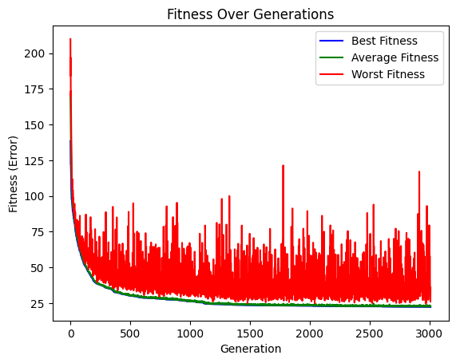

```python
alg.plot_fitness()
```

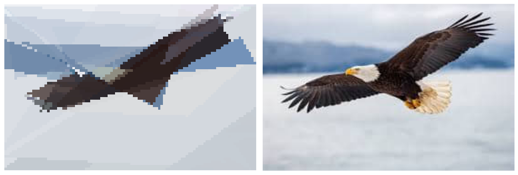

```python
target_image_path_1 = 'C:/Users/Amir/Desktop/دانشگاه/AI/CAs/Genetic-and-Minimax-Algorithms/generation_images/gen_3000.png'
target_image_path_2 = 'C:/Users/Amir/Desktop/دانشگاه/AI/CAs/Genetic-and-Minimax-Algorithms/target_images/eagle.jpg'
image1 = Image.open(target_image_path_1)
image2 = Image.open(target_image_path_2)

fig, axes = plt.subplots(1, 2, figsize=(12, 6))

axes[0].imshow(image1)
axes[0].axis('off')

axes[1].imshow(image2)
axes[1].axis('off')

plt.tight_layout()
plt.show()
```

## Questions

### State Space for One Triangle

The total state space for a single triangle is:

### State Space for the Entire Chromosome

Since there are `100` triangles in a chromosome, the total state space for the chromosome is:

$$ \text{Total State Space} = \left( (width \times height) \times 256^3 \times 100 \times 360 \right)^{100} $$

### Ideas to Speed Up Convergence in Genetic Algorithm

1. **Mutate the Worst Triangle of a Chromosome**

   Instead of mutating a random triangle, mutating only the worst triangle in a chromosome could lead to faster convergence. The idea is that the worst-performing part of the chromosome has the most room for improvement, so applying mutation to it may result in a greater fitness gain.

   **How it helps:**
   - By focusing on improving the worst part of the chromosome, you can speed up convergence by directly addressing the weakest areas.
   - It encourages diversity and exploration in the population, leading to quicker improvements in the solution quality.
2. **Use Crossover with High Probability on Chromosomes with Better Fitness**

   Applying crossover with a higher probability to chromosomes with better fitness allows the genetic algorithm to focus more on combining high-quality solutions. The rationale behind this is that combining the best solutions is likely to produce better offspring, which can speed up the convergence process.

   **How it helps:**
   - By favoring the best-performing chromosomes, crossover increases the likelihood of producing offspring that are closer to the optimal solution.
   - This reduces the time spent exploring poor solutions and helps the algorithm converge to a good solution more quickly.
3. **Use Multithreading to Speed Up Evaluation**

   One technique observed in a similar project on GitHub is the use of multithreading to parallelize the fitness evaluation of chromosomes. By evaluating multiple chromosomes at once using multiple threads, the algorithm can significantly reduce the time it takes to process each generation.

   **How it helps:**
   - Parallelizing the fitness evaluations allows the algorithm to process a larger number of chromosomes in less time, leading to faster convergence.
   - This is especially useful when the fitness calculation is computationally expensive, as it allows multiple fitness evaluations to be done simultaneously.

### Genetic Algorithm Selection Strategies

#### 1. Selection from the Best

In this approach, the algorithm preserves a portion of the top-performing individuals, known as elites, without modification. This allows the best solutions to carry over to the next generation. Specifically, the top 10% of the population based on fitness scores is retained. The remaining individuals are generated through a "best-random pairing" method, where parents are chosen from the top 50% of the population. These parents undergo crossover to produce offspring, followed by mutation, creating diversity in the new generation. This method emphasizes both high-quality individuals and diversity, as only the most fit and a subset of the top half are used to produce the next population.

#### 2. Softmax Selection with Probabilistic Selection

This method incorporates a probability-based selection mechanism to ensure that fitter individuals have a higher likelihood of selection. First, the top 10% of individuals are preserved directly as elites. For the remaining individuals, the algorithm applies a softmax function over the inverted fitness values, transforming the fitness scores into selection probabilities. The resulting probabilities favor individuals with better fitness (lower values). Using these probabilities, parents are selected for reproduction through a technique similar to "roulette wheel selection," where offspring are produced by crossover. Some offspring are randomly chosen to undergo mutation to introduce variation. This approach allows for a more gradual selection of high-performing individuals while preserving diversity, as all population members have a chance of selection.

# Game

```python
import numpy as np
import random
import pygame
import math
from time import sleep, time
from copy import deepcopy

ROW_COUNT = 6
COLUMN_COUNT = 7
SQUARESIZE = 100
RADIUS = int(SQUARESIZE / 2 - 5)
PLAYER = 1
CPU = -1
EMPTY = 0
PLAYER_PIECE = 1
CPU_PIECE = -1
BLUE = (0, 0, 255)
BLACK = (0, 0, 0)
RED = (255, 0, 0)
YELLOW = (255, 255, 0)
WINDOW_LENGTH = 4
WINING_SCORE = 10000000000000
```

```python
class Connect4UI:
    def __init__(self, width=COLUMN_COUNT*SQUARESIZE, height=(ROW_COUNT+1)*SQUARESIZE):
        pygame.init()
        self.width = width
        self.height = height
        self.size = (self.width, self.height)
        self.screen = pygame.display.set_mode(self.size)
        self.font = pygame.font.SysFont("monospace", 75)

    def draw_board(self, board):
        for c in range(COLUMN_COUNT):
            for r in range(ROW_COUNT):
                pygame.draw.rect(self.screen, BLUE, (c * SQUARESIZE, r * SQUARESIZE + SQUARESIZE, SQUARESIZE, SQUARESIZE))
                pygame.draw.circle(self.screen, BLACK, (int(c * SQUARESIZE + SQUARESIZE / 2), int(r * SQUARESIZE + SQUARESIZE + SQUARESIZE / 2)), RADIUS)

        for c in range(COLUMN_COUNT):
            for r in range(ROW_COUNT):
                if board[r][c] == PLAYER_PIECE:
                    pygame.draw.circle(self.screen, RED, (int(c * SQUARESIZE + SQUARESIZE / 2), self.height - int(r * SQUARESIZE + SQUARESIZE / 2)), RADIUS)
                elif board[r][c] == CPU_PIECE:
                    pygame.draw.circle(self.screen, YELLOW, (int(c * SQUARESIZE + SQUARESIZE / 2), self.height - int(r * SQUARESIZE + SQUARESIZE / 2)), RADIUS)

        pygame.display.update()
        sleep(0.2)


    def display_winner(self, winner):
        if winner == PLAYER:
            label = self.font.render("Player wins!!", 1, RED)
        elif winner == CPU:
            label = self.font.render("Computer wins!!", 1, YELLOW)
        else:
            label = self.font.render("It's a draw!!", 1, BLUE)
        self.screen.blit(label, (40, 10))
        pygame.display.update()
        sleep(5)
```

```python
class Connect4Game:
    def __init__(self, ui, minimax_depth, prune):
        self.board = np.zeros((ROW_COUNT, COLUMN_COUNT))
        self.ui = Connect4UI() if ui else None
        self.minimax_depth = minimax_depth
        self.prune = prune
        self.current_turn = random.choice([1, -1])
        self.nodes_seen_count = 0

    def drop_piece(self, board, row, col, piece):
        board[row][col] = piece

    def get_next_open_row(self, board,col):
        for r in range(ROW_COUNT):
            if board[r][col] == 0:
                return r

    def print_board(self, board):
        print(np.flip(board, 0))

    def winning_move(self, board, piece):
        for c in range(COLUMN_COUNT - 3):
            for r in range(ROW_COUNT):
                if all(board[r][c+i] == piece for i in range(WINDOW_LENGTH)):
                    return True

        for c in range(COLUMN_COUNT):
            for r in range(ROW_COUNT - 3):
                if all(board[r+i][c] == piece for i in range(WINDOW_LENGTH)):
                    return True

        for c in range(COLUMN_COUNT - 3):
            for r in range(ROW_COUNT - 3):
                if all(board[r+i][c+i] == piece for i in range(WINDOW_LENGTH)):
                    return True

        for c in range(COLUMN_COUNT - 3):
            for r in range(3, ROW_COUNT):
                if all(board[r-i][c+i] == piece for i in range(WINDOW_LENGTH)):
                    return True

        return False

    def evaluate_window(self, window, piece):
        score = 0
        opp_piece = PLAYER_PIECE
        if piece == PLAYER_PIECE:
            opp_piece = CPU_PIECE

        if window.count(piece) == 4:
            score += 100
        elif window.count(piece) == 3 and window.count(EMPTY) == 1:
            score += 5
        elif window.count(piece) == 2 and window.count(EMPTY) == 2:
            score += 2
        if window.count(opp_piece) == 3 and window.count(EMPTY) == 1:
            score -= 4

        return score

    def score_position(self, board, piece):
        score = 0
        center_array = [int(i) for i in list(board[:, COLUMN_COUNT//2])]
        center_count = center_array.count(piece)
        score += center_count * 3

        for r in range(ROW_COUNT):
            row_array = [int(i) for i in list(board[r,:])]
            for c in range(COLUMN_COUNT-3):
                window = row_array[c:c+WINDOW_LENGTH]
                score += self.evaluate_window(window, piece)

        for c in range(COLUMN_COUNT):
            col_array = [int(i) for i in list(board[:,c])]
            for r in range(ROW_COUNT-3):
                window = col_array[r:r+WINDOW_LENGTH]
                score += self.evaluate_window(window, piece)

        for r in range(ROW_COUNT-3):
            for c in range(COLUMN_COUNT-3):
                window = [board[r+i][c+i] for i in range(WINDOW_LENGTH)]
                score += self.evaluate_window(window, piece)

        for r in range(ROW_COUNT-3):
            for c in range(COLUMN_COUNT-3):
                window = [board[r+3-i][c+i] for i in range(WINDOW_LENGTH)]
                score += self.evaluate_window(window, piece)

        return score

    def is_terminal_node(self, board):
        return self.winning_move(board, PLAYER_PIECE) or self.winning_move(board, CPU_PIECE) or len(self.get_valid_locations(board)) == 0

    def get_valid_locations(self, board):
        valid_locations = []
        for col in range(COLUMN_COUNT):
            if board[ROW_COUNT-1][col] == 0:
                valid_locations.append(col)
        return valid_locations

    def best_cpu_score(self, board, moves):
        move = None
        max_score = -math.inf
        for col in moves:
            row = self.get_next_open_row(board, col)
            b_copy = board.copy()
            self.drop_piece(b_copy, row, col, CPU_PIECE)
            score = self.heuristic(b_copy, CPU_PIECE)
            if score > max_score:
                max_score = score
                move = col
        return move

    def heuristic(self, board, piece):
        if(self.is_terminal_node(board)):
            if self.winning_move(board, piece):
                return WINING_SCORE
            elif self.winning_move(board, -piece):
                return -WINING_SCORE
            else:
                return 0
        else:
            return self.score_position(board, piece) - self.score_position(board, -piece)

    def minimax(self, board, depth, alpha, beta, player):
        self.nodes_seen_count += 1
        valid_locations = self.get_valid_locations(board)
        is_terminal = self.is_terminal_node(board)
        if depth == 0 or is_terminal:
            return None, self.heuristic(board, PLAYER_PIECE)

        if player == PLAYER_PIECE:
            max_score = -math.inf
            best_col = None

            for col in valid_locations:
                row = self.get_next_open_row(deepcopy(board), col)
                b_copy = deepcopy(board)
                self.drop_piece(b_copy, row, col, PLAYER_PIECE)
                _ , score = self.minimax(b_copy, depth - 1, alpha, beta, CPU_PIECE)
                if score > max_score:
                    max_score = score
                    best_col = col
                alpha = max(alpha, max_score)
                if self.prune and beta <= alpha:
                    break
            return best_col, max_score

        else:
            min_score = math.inf
            best_col = None

            for col in valid_locations:
                row = self.get_next_open_row(deepcopy(board), col)
                b_copy = deepcopy(board)
                self.drop_piece(b_copy, row, col, CPU_PIECE)
                _ , score = self.minimax(b_copy, depth - 1, alpha, beta, PLAYER_PIECE)
                if score < min_score:
                    min_score = score
                    best_col = col
                beta = min(beta, min_score)
                if beta <= alpha and self.prune:
                    break
            return best_col, min_score

    def get_cpu_move(self, board, randomness_percent=30):
        moves = self.get_valid_locations(board)
        if len(moves) == 0:
            return None
        random_move = random.choice(moves)
        score_move = self.best_cpu_score(board, moves)
        move = random.choice([score_move] * (100 - randomness_percent) + [random_move] * randomness_percent)
        return move, self.get_next_open_row(board, move)


    def get_human_move(self, board, depth = 1):
        col = self.minimax(board, depth, -math.inf, math.inf, self.current_turn)[0]
        return col, self.get_next_open_row(board, col)

    def play(self):
        self.nodes_seen_count = 0
        winner = None
        while not self.is_terminal_node(self.board):
            if self.ui:
                self.ui.draw_board(self.board)
            if self.current_turn == PLAYER:
                col, row = self.get_human_move(self.board, self.minimax_depth)
                if col is not None:
                    self.drop_piece(self.board, row, col, PLAYER_PIECE)
                    if self.winning_move(self.board, PLAYER_PIECE):
                        winner = PLAYER
                    self.current_turn = CPU
            else:
                col, row = self.get_cpu_move(self.board)
                if col is not None:
                    self.drop_piece(self.board, row, col, CPU_PIECE)
                    if self.winning_move(self.board, CPU_PIECE):
                        winner = CPU
                    self.current_turn = PLAYER

            if self.ui:
                self.ui.draw_board(self.board)
                if winner is not None:
                    self.ui.display_winner(winner)

        if winner is None:
            winner = 0
        return winner

    def get_nodes_seen(self):
        return self.nodes_seen_count
```

Complete the Connect4Game class below by implementing the `minimax algorithm` with `alpha-beta pruning` and `depth limiting`. Don't change other parts of the code unless you want to define a new heuristic function.

```python
def print_results(results, depth, pruning, start, end):
    pruning_status = "Enabled" if pruning else "Disabled"
    print(
        f'Depth: {depth} | Pruning: {pruning_status} -> User Wins: {results[1]:3}, CPU Wins: {results[-1]:2}, Ties: {results[0]:2}, Time: {end - start:.2f}s'
    )
```

Use the code below to test the game with the UI. Pygame is not compatible with Jupyter Notebook and will not work in this environment. To use Pygame, please run the code in a separate `.py` file.

```python
# game = Connect4Game(True, 3, True)
# game.play()
```

Run the following code to test the results of the game and the time taken to play the game in different `depths` and with `pruning` enabled and disabled.

```python
def check_results():
    for pruning in [True, False]:
        for d in range(1, 4):
            results = {-1: 0, 0: 0, 1: 0}
            start = time()
            for _ in range(20):
                game = Connect4Game(False, d, pruning)
                results[game.play()] += 1
            end = time()
            print_results(results, d, pruning, start, end)

check_results()
```

```
Depth: 1 | Pruning: Enabled -> User Wins:  15, CPU Wins:  5, Ties:  0, Time: 0.95s
Depth: 2 | Pruning: Enabled -> User Wins:  20, CPU Wins:  0, Ties:  0, Time: 4.20s
Depth: 3 | Pruning: Enabled -> User Wins:  19, CPU Wins:  1, Ties:  0, Time: 11.84s
Depth: 1 | Pruning: Disabled -> User Wins:  10, CPU Wins: 10, Ties:  0, Time: 0.81s
Depth: 2 | Pruning: Disabled -> User Wins:  20, CPU Wins:  0, Ties:  0, Time: 4.29s
Depth: 3 | Pruning: Disabled -> User Wins:  19, CPU Wins:  1, Ties:  0, Time: 29.44s
```

## Analysis of Connect 4 Game Performance by Depth

```python
import time
import matplotlib.pyplot as plt

def simulate_game(depth, pruning, runs):
    results = {-1: 0, 0: 0, 1: 0}
    total_time = 0
    total_nodes = 0

    for _ in range(runs):
        game = Connect4Game(False, depth, pruning)
        start_time = time.time()

        outcome = game.play()

        elapsed_time = time.time() - start_time
        nodes_seen = game.get_nodes_seen()

        results[outcome] += 1
        total_time += elapsed_time
        total_nodes += nodes_seen

    avg_time = total_time / runs
    win_prob = results[1] / runs
    avg_nodes = total_nodes / runs

    return avg_time, win_prob, avg_nodes

def run_analysis(depths, pruning, runs):
    times, win_probs, node_counts = [], [], []

    for depth in depths:
        avg_time, win_prob, avg_nodes = simulate_game(depth, pruning=pruning, runs=runs)

        times.append(avg_time)
        win_probs.append(win_prob)
        node_counts.append(avg_nodes)

        print(f"Depth {depth} -> Avg Time: {avg_time:.2f}s, Win Prob: {win_prob:.2f}, Avg Nodes: {avg_nodes}")

    # show plots
    plt.figure(figsize=(15, 5))

    plt.subplot(1, 3, 1)
    plt.plot(depths, times, marker='o')
    plt.title("Average Time vs Depth")
    plt.xlabel("Depth")
    plt.ylabel("Average Time (s)")

    plt.subplot(1, 3, 2)
    plt.plot(depths, win_probs, marker='o')
    plt.title("Winning Probability vs Depth")
    plt.xlabel("Depth")
    plt.ylabel("Probability of Winning")

    plt.subplot(1, 3, 3)
    plt.plot(depths, node_counts, marker='o')
    plt.title("Average Nodes Seen vs Depth")
    plt.xlabel("Depth")
    plt.ylabel("Average Nodes Seen")

    plt.tight_layout()
    plt.show()
```

### Analysis of Connect 4 Game Performance by Depth (Without Pruning)

```
Depth 1 -> Avg Time: 0.05s, Win Prob: 0.70, Avg Nodes: 40.62
Depth 2 -> Avg Time: 0.28s, Win Prob: 0.96, Avg Nodes: 371.48
Depth 3 -> Avg Time: 1.81s, Win Prob: 0.98, Avg Nodes: 2464.2
```

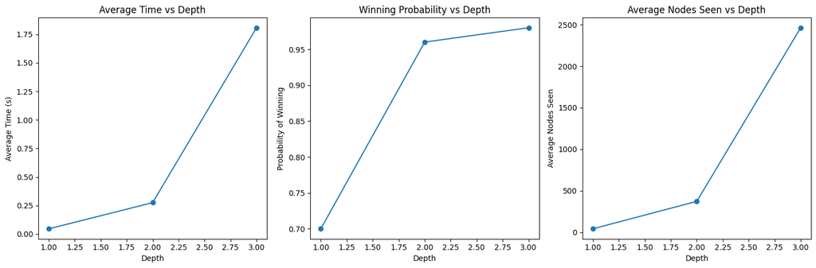

```python
depths = range(1, 4)
runs = 50
run_analysis(depths, False, runs)
```

### Analysis of Connect 4 Game Performance by Depth (With Pruning)

```
Depth 1 -> Avg Time: 0.04s, Win Prob: 0.70, Avg Nodes: 43.16
Depth 2 -> Avg Time: 0.19s, Win Prob: 0.98, Avg Nodes: 274.42
Depth 3 -> Avg Time: 0.63s, Win Prob: 1.00, Avg Nodes: 1024.72
```

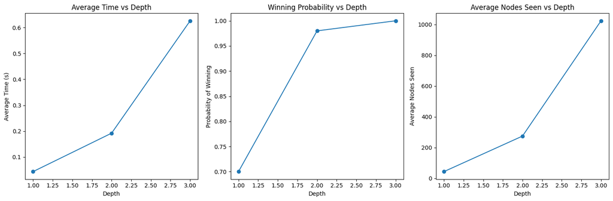

```python
depths = range(1, 4)
runs = 50
run_analysis(depths, True, runs)
```

## Questions

### Relationship Between Depth and Calculated Parameters in the Minimax Algorithm

1. **Depth and Calculated Parameters**  
   In the Minimax algorithm, the **depth** refers to how many layers of moves the algorithm explores before making a decision. As the depth increases:
   - **Chance of Winning:** A deeper search allows the algorithm to evaluate more potential future moves, which can improve the decision-making process and increase the chances of winning. However, this improvement is limited as deeper levels may not always provide significantly better decisions if the evaluation function is not accurate.
   - **Time:** The time complexity increases exponentially with depth. As the depth increases, the algorithm must evaluate more nodes, leading to longer computation times. This happens because the number of possible game states grows exponentially with each move (i.e., O(b^d), where b is the branching factor and d is the depth).
   - **Nodes Seen:** The number of nodes the algorithm needs to explore increases significantly with the depth. The search space grows exponentially, leading to more nodes being explored at higher depths. This is one of the main challenges of using Minimax in games with large search spaces.

   Therefore, increasing the depth enhances decision-making but at the cost of increased time and nodes explored, which may limit its practical application for real-time or resource-constrained environments.

### Can We Choose the Order of Seeing the Children of Each Node to Maximize Pruning?

Yes, we can choose the order in which we explore the children of each node to maximize pruning, and this technique is known as **Move Ordering**.

1. **Pruning in Minimax Algorithm**

   Pruning occurs when the algorithm skips evaluating certain branches of the game tree because it knows that these branches cannot affect the final decision. This is done through **Alpha-Beta Pruning**, where the algorithm keeps track of two values (alpha and beta) that represent the best possible scores for the maximizing and minimizing players, respectively.
2. **Method for Maximizing Pruning**

   To maximize pruning, we need to explore the most promising moves first. If we order the children of each node such that the most likely moves to lead to a favorable outcome are explored first, the algorithm is more likely to prune unimportant branches earlier.
   - **Maximizing Pruning:** By evaluating the most promising moves first (those likely to lead to a high score for the maximizing player or low score for the minimizing player), the algorithm will find a good value for alpha and beta sooner, leading to more effective pruning of unimportant branches.
3. **How to Implement This?**
   - **Heuristic-based Ordering:** One way to order the children is to use a heuristic evaluation function that estimates the potential value of each move before exploring the full game tree.
   - **Transposition Tables:** Another approach is using transposition tables to store previously computed values for certain game states, which helps in deciding which branches to explore.

   By ordering the children in this way, we can maximize pruning, making the algorithm more efficient and reducing the number of nodes explored.

### Branching Factor and Its Changes with Game Development

1. **Branching Factor**

   The **branching factor** refers to the number of possible moves (or children) that can be generated from a given node in the game tree. In the context of the **Minimax algorithm**, the branching factor determines the number of nodes that the algorithm needs to evaluate at each level of the search tree. A larger branching factor means more potential moves to explore, leading to higher computational complexity.

   For example, in a game like **Connect 4**, at each turn, the number of possible moves corresponds to the number of empty columns where a player can drop a piece. If the board is nearly full, the branching factor is smaller, but if many moves are available, the branching factor increases.
2. **Changes with Game Development**

   As the game progresses and the player or the AI gains experience, the following changes may occur in the branching factor:
   - **Early Game:** In the beginning of the game, when the board is mostly empty, the branching factor is relatively high because many moves are possible. As players continue to make moves, the number of available moves gradually decreases.
   - **Mid and Late Game:** As more pieces are placed, the game space becomes more constrained, and the branching factor typically reduces. For the AI, focusing on key positions and reducing unnecessary exploration can help manage this.
   - **AI-Driven Development:** With further game development, especially incorporating AI with advanced techniques like **Alpha-Beta Pruning** and **Heuristic Evaluation**, the effective branching factor can be reduced, as many branches of the search tree may be pruned early, leading to more efficient decision-making.

   In summary, the branching factor will change dynamically depending on the game state, and strategies for pruning and move selection can help manage its impact on performance.

### Why Does the Algorithm Become Faster Without Losing Accuracy When Pruning?

Pruning, specifically **Alpha-Beta Pruning**, makes the Minimax algorithm faster by eliminating branches in the game tree that cannot affect the final decision.

1. **How Pruning Works**

   During Minimax search, **Alpha-Beta Pruning** keeps track of two values:
   - **Alpha**: the best score that the maximizing player can guarantee at that point.
   - **Beta**: the best score that the minimizing player can guarantee at that point.

   If, while exploring a node, it becomes clear that it will not affect the outcome (i.e., it falls outside the alpha-beta range), the algorithm **prunes** that branch, skipping further evaluation of that node.
2. **Improving Speed Without Losing Accuracy**

   By pruning irrelevant branches, the algorithm can **focus on critical moves** while ignoring those that do not affect the final decision. This significantly reduces the number of nodes evaluated, making the algorithm faster without affecting the accuracy of the outcome, as it still explores all possible moves that could change the result.

In summary, pruning enhances the efficiency of the Minimax algorithm, allowing it to search deeper or run faster by ignoring branches that do not influence the final decision.

### Why Use Minimax When the Opponent Acts by Chance? Is It the Optimal Method?

1. **Limitations of Minimax with Random Opponents**

   Minimax is designed to anticipate an opponent's optimal moves by assuming they make decisions to maximize their own advantage. However, when the opponent acts **randomly or unpredictably**, Minimax may not be the most effective method. Since it assumes the opponent will make the best move, it may lead to suboptimal decision-making against a non-strategic, chance-driven opponent.

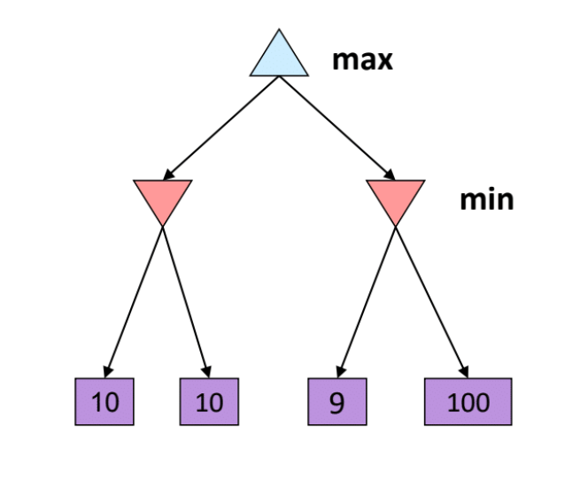

2. **Alternative Algorithm: Expectimax**

   A better-suited algorithm for situations where the opponent’s moves are random is **Expectimax**:
   - **How Expectimax Works**: Instead of assuming an optimal opponent, Expectimax accounts for the **probabilities of each possible move**. It evaluates moves by calculating the expected utility, averaging the values based on the probability of each potential random move.
   - **Advantages Over Minimax**: Expectimax is more appropriate for games involving randomness, as it can handle both strategic moves and chance-based events, leading to more realistic and adaptive decisions.

In summary, **Expectimax** is often a better choice than Minimax in scenarios where an opponent behaves unpredictably or moves randomly, as it provides a probability-weighted evaluation that aligns better with the stochastic nature of the opponent's moves.